# Modul 02 - R for Data Analysis

Roni Yunis

17/09/2024

# Membaca dataset

Setelah memahami dasar dari pemerograman R seperti tipe dan struktur data, sekarang kita akan membahas bagaimana cara mengimport dan membaca dataset pada R. Import dataset pada R dapat dilakukan melalui 2 cara:

1. Melalui melalui menu import dataset pada tab menu File.
2. Melalui upload file pada panel file.

Import dataset tergantung dari jenis format file dari dataset tersebut, ada yang berformat excel, csv, xlsx, dll. Dalam contoh ini kita sudah mengimport dataset pada folder data, dan bisa dilihat pada panel file yang menampung 3 buah dataset dengan format yang berbeda yaitu format: .csv, .xlsx dan .xls

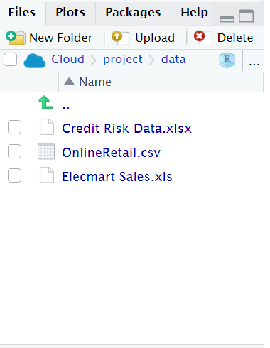

## data csv

Untuk membaca data dengan format .csv pada R bisa menggunakan fungsi `read.csv()`.

```r
retail <- read.csv("data/OnlineRetail.csv")
retail
```

| InvoiceNo | StockCode | Description | Quantity | InvoiceDate | UnitPrice | CustomerID | Country |
| --- | --- | --- | --- | --- | --- | --- | --- |
| 536365 | 85123A | white hanging heart t-light holder | 6 | 12/1/2010 8:26 | 2.55 | 17850 | United Kingdom |
| 536365 | 71053 | white metal lantern | 6 | 12/1/2010 8:26 | 3.39 | 17850 | United Kingdom |
| 536365 | 84406B | cream cupid hearts coat hanger | 8 | 12/1/2010 8:26 | 2.75 | 17850 | United Kingdom |
| 536365 | 84029G | knitted union flag hot water bottle | 6 | 12/1/2010 8:26 | 3.39 | 17850 | United Kingdom |
| 536365 | 84029E | red woolly hottie white heart. | 6 | 12/1/2010 8:26 | 3.39 | 17850 | United Kingdom |
| 536365 | 22752 | set 7 babushka nesting boxes | 2 | 12/1/2010 8:26 | 7.65 | 17850 | United Kingdom |
| 536365 | 21730 | glass star frosted t-light holder | 6 | 12/1/2010 8:26 | 4.25 | 17850 | United Kingdom |
| 536366 | 22633 | hand warmer union jack | 6 | 12/1/2010 8:28 | 1.85 | 17850 | United Kingdom |
| 536366 | 22632 | hand warmer red polka dot | 6 | 12/1/2010 8:28 | 1.85 | 17850 | United Kingdom |
| 536367 | 84879 | assorted colour bird ornament | 32 | 12/1/2010 8:34 | 1.69 | 13047 | United Kingdom |

[output cut: 9990 more lines]

setelah kita jalankan fungsi diatas maka nanti pada panel environment yang terbentuk sebuah data dengan nama *retail*

*Latihan: Import dan baca dataset Diabetes.csv*

```r
library(readr)
diabetes <- read_csv("data/diabetes.csv")
diabetes
```

| Pregnancies | Glucose | BloodPressure | SkinThickness | Insulin | BMI | DiabetesPedigreeFunction | Age | Outcome |
| --- | --- | --- | --- | --- | --- | --- | --- | --- |
| 6 | 148 | 72 | 35 | 0 | 33.6 | 0.627 | 50 | 1 |
| 1 | 85 | 66 | 29 | 0 | 26.6 | 0.351 | 31 | 0 |
| 8 | 183 | 64 | 0 | 0 | 23.3 | 0.672 | 32 | 1 |
| 1 | 89 | 66 | 23 | 94 | 28.1 | 0.167 | 21 | 0 |
| 0 | 137 | 40 | 35 | 168 | 43.1 | 2.288 | 33 | 1 |
| 5 | 116 | 74 | 0 | 0 | 25.6 | 0.201 | 30 | 0 |
| 3 | 78 | 50 | 32 | 88 | 31.0 | 0.248 | 26 | 1 |
| 10 | 115 | 0 | 0 | 0 | 35.3 | 0.134 | 29 | 0 |
| 2 | 197 | 70 | 45 | 543 | 30.5 | 0.158 | 53 | 1 |
| 8 | 125 | 96 | 0 | 0 | 0.0 | 0.232 | 54 | 1 |

[output cut: 758 more lines]

```r
diabetes
```

| Pregnancies | Glucose | BloodPressure | SkinThickness | Insulin | BMI | DiabetesPedigreeFunction | Age | Outcome |
| --- | --- | --- | --- | --- | --- | --- | --- | --- |
| 6 | 148 | 72 | 35 | 0 | 33.6 | 0.627 | 50 | 1 |
| 1 | 85 | 66 | 29 | 0 | 26.6 | 0.351 | 31 | 0 |
| 8 | 183 | 64 | 0 | 0 | 23.3 | 0.672 | 32 | 1 |
| 1 | 89 | 66 | 23 | 94 | 28.1 | 0.167 | 21 | 0 |
| 0 | 137 | 40 | 35 | 168 | 43.1 | 2.288 | 33 | 1 |
| 5 | 116 | 74 | 0 | 0 | 25.6 | 0.201 | 30 | 0 |
| 3 | 78 | 50 | 32 | 88 | 31.0 | 0.248 | 26 | 1 |
| 10 | 115 | 0 | 0 | 0 | 35.3 | 0.134 | 29 | 0 |
| 2 | 197 | 70 | 45 | 543 | 30.5 | 0.158 | 53 | 1 |
| 8 | 125 | 96 | 0 | 0 | 0.0 | 0.232 | 54 | 1 |

[output cut: 758 more lines]

## data excel(.xls)/(.xlsx)

Untuk membaca data dengan format excel atau .xls, dan .xlsx, kita harus menginstall sebuah packages yaitu “readxl”, untuk install packages nanti akan dibahas pada bagian khusus dibawah. Setelah packages berhasil di install, maka kita harus aktifkan packages tersebut dengan perintah seperti ini:

```r
#panggil library readxl
library(readxl)
```

Setelah library “readxl” berhasil dipanggil, maka untuk membaca file .xls bisa menggunakan fungsi `read_excel()`

```r
sales <- read_excel("data/Elecmart Sales.xls", sheet = "Data")
sales
```

| Date | Day | Time | Region | Card Type | Gender | Buy Category | Items Ordered | Total Cost | High Item |
| --- | --- | --- | --- | --- | --- | --- | --- | --- | --- |
| 2016-03-06 | Sun | Morning | West | ElecMart | Female | High | 4 | 136.97 | 79.97 |
| 2016-03-06 | Sun | Morning | West | Other | Female | Medium | 1 | 25.55 | 25.55 |
| 2016-03-06 | Sun | Afternoon | West | ElecMart | Female | Medium | 5 | 113.95 | 90.47 |
| 2016-03-06 | Sun | Afternoon | NorthEast | Other | Female | Low | 1 | 6.82 | 6.82 |
| 2016-03-06 | Sun | Afternoon | West | ElecMart | Male | Medium | 4 | 147.32 | 83.21 |
| 2016-03-06 | Sun | Afternoon | NorthEast | Other | Female | Medium | 5 | 142.15 | 50.90 |
| 2016-03-07 | Mon | Evening | West | Other | Male | Low | 1 | 18.65 | 18.65 |
| 2016-03-07 | Mon | Evening | South | Other | Male | High | 4 | 178.34 | 161.93 |
| 2016-03-07 | Mon | Evening | West | Other | Male | Low | 2 | 25.83 | 15.91 |
| 2016-03-08 | Tue | Morning | MidWest | Other | Female | Low | 1 | 18.13 | 18.13 |

[output cut: 390 more lines]

“sheet” menunjukkan nama sheet atau nomor sheet yang ada pada file excel tersebut.

Untuk membaca data dengan format .xlsx, caranya sama dengan yang sebelumnya

```r
risk <- read_excel("data/Credit Risk Data.xlsx", sheet = "Base Data")
```

```r
risk
```

| LoanPurpose | Checking | Savings | MonthsCustomer | MonthsEmployed | Gender | MaritalStatus | Age | Housing | Years | Job | CreditRisk |
| --- | --- | --- | --- | --- | --- | --- | --- | --- | --- | --- | --- |
| Small Appliance | 0 | 739 | 13 | 12 | M | Single | 23 | Own | 3 | Unskilled | Low |
| Furniture | 0 | 1230 | 25 | 0 | M | Divorced | 32 | Own | 1 | Skilled | High |
| New Car | 0 | 389 | 19 | 119 | M | Single | 38 | Own | 4 | Management | High |
| Furniture | 638 | 347 | 13 | 14 | M | Single | 36 | Own | 2 | Unskilled | High |
| Education | 963 | 4754 | 40 | 45 | M | Single | 31 | Rent | 3 | Skilled | Low |
| Furniture | 2827 | 0 | 11 | 13 | M | Married | 25 | Own | 1 | Skilled | Low |
| New Car | 0 | 229 | 13 | 16 | M | Married | 26 | Own | 3 | Unskilled | Low |
| Business | 0 | 533 | 14 | 2 | M | Single | 27 | Own | 1 | Unskilled | Low |
| Small Appliance | 6509 | 493 | 37 | 9 | M | Single | 25 | Own | 2 | Skilled | High |
| Small Appliance | 966 | 0 | 25 | 4 | F | Divorced | 43 | Own | 1 | Skilled | High |

[output cut: 415 more lines]

# Memeriksa isi dataset

## str()

Fungsi `str()` digunakan untuk melihat struktur dan variabel dari data. Misalkan kita akan melihat struktur data dari objek *retail* yang sebelumnya kita gunakan untuk menyimpan data “OnlineRetail.csv”. Cara menggunakan fungsi `str()` adalah:

```r
str(retail)
```

```
## 'data.frame':    541909 obs. of  8 variables:
##  $ InvoiceNo  : chr  "536365" "536365" "536365" "536365" ...
##  $ StockCode  : chr  "85123A" "71053" "84406B" "84029G" ...
##  $ Description: chr  "white hanging heart t-light holder" "white metal lantern" "cream cupid hearts coat hanger" "knitted union flag hot water bottle" ...
##  $ Quantity   : int  6 6 8 6 6 2 6 6 6 32 ...
##  $ InvoiceDate: chr  "12/1/2010 8:26" "12/1/2010 8:26" "12/1/2010 8:26" "12/1/2010 8:26" ...
##  $ UnitPrice  : num  2.55 3.39 2.75 3.39 3.39 7.65 4.25 1.85 1.85 1.69 ...
##  $ CustomerID : int  17850 17850 17850 17850 17850 17850 17850 17850 17850 13047 ...
##  $ Country    : chr  "United Kingdom" "United Kingdom" "United Kingdom" "United Kingdom" ...
```

kalau fungsi `str(retail)` tersebut kita jalankan, maka akan memperlihat struktur data (jumlah baris dan jumlah kolom), dan variabel-variabel dari data beserta dengan type datanya.

*Latihan* GUnakalah fungsi `str()` untuk melihat struktur data dari objek `risk` dan `sales`

```r
# your code
str(risk)
```

```
## tibble [425 × 12] (S3: tbl_df/tbl/data.frame)
##  $ LoanPurpose   : chr [1:425] "Small Appliance" "Furniture" "New Car" "Furniture" ...
##  $ Checking      : num [1:425] 0 0 0 638 963 ...
##  $ Savings       : num [1:425] 739 1230 389 347 4754 ...
##  $ MonthsCustomer: num [1:425] 13 25 19 13 40 11 13 14 37 25 ...
##  $ MonthsEmployed: num [1:425] 12 0 119 14 45 13 16 2 9 4 ...
##  $ Gender        : chr [1:425] "M" "M" "M" "M" ...
##  $ MaritalStatus : chr [1:425] "Single" "Divorced" "Single" "Single" ...
##  $ Age           : num [1:425] 23 32 38 36 31 25 26 27 25 43 ...
##  $ Housing       : chr [1:425] "Own" "Own" "Own" "Own" ...
##  $ Years         : num [1:425] 3 1 4 2 3 1 3 1 2 1 ...
##  $ Job           : chr [1:425] "Unskilled" "Skilled" "Management" "Unskilled" ...
##  $ CreditRisk    : chr [1:425] "Low" "High" "High" "High" ...
```

```r
str(sales)
```

```
## tibble [400 × 10] (S3: tbl_df/tbl/data.frame)
##  $ Date         : POSIXct[1:400], format: "2016-03-06" "2016-03-06" ...
##  $ Day          : chr [1:400] "Sun" "Sun" "Sun" "Sun" ...
##  $ Time         : chr [1:400] "Morning" "Morning" "Afternoon" "Afternoon" ...
##  $ Region       : chr [1:400] "West" "West" "West" "NorthEast" ...
##  $ Card Type    : chr [1:400] "ElecMart" "Other" "ElecMart" "Other" ...
##  $ Gender       : chr [1:400] "Female" "Female" "Female" "Female" ...
##  $ Buy Category : chr [1:400] "High" "Medium" "Medium" "Low" ...
##  $ Items Ordered: num [1:400] 4 1 5 1 4 5 1 4 2 1 ...
##  $ Total Cost   : num [1:400] 136.97 25.55 113.95 6.82 147.32 ...
##  $ High Item    : num [1:400] 79.97 25.55 90.47 6.82 83.21 ...
```

*Latihan* gunakan fungsi `str()` untuk melihat struktur data dari objek `diabetes`

```r
# your code
```

## Head()

Fungsi `head()` digunakan untuk menampilkan 6 data teratas dari dataset. Misalnya kita akan melihat 6 data teratas dari objek *retail*, maka cara menggunakan fungsi `head()` adalah sebagai berikut:

```r
head(retail)
```

|  | InvoiceNo | StockCode | Description | Quantity | InvoiceDate | UnitPrice | CustomerID | Country |
| --- | --- | --- | --- | --- | --- | --- | --- | --- |
| 1 | 536365 | 85123A | white hanging heart t-light holder | 6 | 12/1/2010 8:26 | 2.55 | 17850 | United Kingdom |
| 2 | 536365 | 71053 | white metal lantern | 6 | 12/1/2010 8:26 | 3.39 | 17850 | United Kingdom |
| 3 | 536365 | 84406B | cream cupid hearts coat hanger | 8 | 12/1/2010 8:26 | 2.75 | 17850 | United Kingdom |
| 4 | 536365 | 84029G | knitted union flag hot water bottle | 6 | 12/1/2010 8:26 | 3.39 | 17850 | United Kingdom |
| 5 | 536365 | 84029E | red woolly hottie white heart. | 6 | 12/1/2010 8:26 | 3.39 | 17850 | United Kingdom |
| 6 | 536365 | 22752 | set 7 babushka nesting boxes | 2 | 12/1/2010 8:26 | 7.65 | 17850 | United Kingdom |

```r
# Menampilkan 3 data teratas
head(retail,3)
```

|  | InvoiceNo | StockCode | Description | Quantity | InvoiceDate | UnitPrice | CustomerID | Country |
| --- | --- | --- | --- | --- | --- | --- | --- | --- |
| 1 | 536365 | 85123A | white hanging heart t-light holder | 6 | 12/1/2010 8:26 | 2.55 | 17850 | United Kingdom |
| 2 | 536365 | 71053 | white metal lantern | 6 | 12/1/2010 8:26 | 3.39 | 17850 | United Kingdom |
| 3 | 536365 | 84406B | cream cupid hearts coat hanger | 8 | 12/1/2010 8:26 | 2.75 | 17850 | United Kingdom |

*Latihan*

1. Gunakan fungsi `head()` untuk menampilkan 6 data teratas dari objek `risk`
2. Gunakan fungsi `head()` untuk menampikan 9 data teratas dari objek `sales`
3. Gunakan fungsi `head()` untuk menampikan 15 data teratas dari objek `diabetes`

```r
# your code
head(risk)
```

| LoanPurpose | Checking | Savings | MonthsCustomer | MonthsEmployed | Gender | MaritalStatus | Age | Housing | Years | Job | CreditRisk |
| --- | --- | --- | --- | --- | --- | --- | --- | --- | --- | --- | --- |
| Small Appliance | 0 | 739 | 13 | 12 | M | Single | 23 | Own | 3 | Unskilled | Low |
| Furniture | 0 | 1230 | 25 | 0 | M | Divorced | 32 | Own | 1 | Skilled | High |
| New Car | 0 | 389 | 19 | 119 | M | Single | 38 | Own | 4 | Management | High |
| Furniture | 638 | 347 | 13 | 14 | M | Single | 36 | Own | 2 | Unskilled | High |
| Education | 963 | 4754 | 40 | 45 | M | Single | 31 | Rent | 3 | Skilled | Low |
| Furniture | 2827 | 0 | 11 | 13 | M | Married | 25 | Own | 1 | Skilled | Low |

```r
head(sales, 9)
```

| Date | Day | Time | Region | Card Type | Gender | Buy Category | Items Ordered | Total Cost | High Item |
| --- | --- | --- | --- | --- | --- | --- | --- | --- | --- |
| 2016-03-06 | Sun | Morning | West | ElecMart | Female | High | 4 | 136.97 | 79.97 |
| 2016-03-06 | Sun | Morning | West | Other | Female | Medium | 1 | 25.55 | 25.55 |
| 2016-03-06 | Sun | Afternoon | West | ElecMart | Female | Medium | 5 | 113.95 | 90.47 |
| 2016-03-06 | Sun | Afternoon | NorthEast | Other | Female | Low | 1 | 6.82 | 6.82 |
| 2016-03-06 | Sun | Afternoon | West | ElecMart | Male | Medium | 4 | 147.32 | 83.21 |
| 2016-03-06 | Sun | Afternoon | NorthEast | Other | Female | Medium | 5 | 142.15 | 50.90 |
| 2016-03-07 | Mon | Evening | West | Other | Male | Low | 1 | 18.65 | 18.65 |
| 2016-03-07 | Mon | Evening | South | Other | Male | High | 4 | 178.34 | 161.93 |
| 2016-03-07 | Mon | Evening | West | Other | Male | Low | 2 | 25.83 | 15.91 |

```r
head(sales, 25)
```

| Date | Day | Time | Region | Card Type | Gender | Buy Category | Items Ordered | Total Cost | High Item |
| --- | --- | --- | --- | --- | --- | --- | --- | --- | --- |
| 2016-03-06 | Sun | Morning | West | ElecMart | Female | High | 4 | 136.97 | 79.97 |
| 2016-03-06 | Sun | Morning | West | Other | Female | Medium | 1 | 25.55 | 25.55 |
| 2016-03-06 | Sun | Afternoon | West | ElecMart | Female | Medium | 5 | 113.95 | 90.47 |
| 2016-03-06 | Sun | Afternoon | NorthEast | Other | Female | Low | 1 | 6.82 | 6.82 |
| 2016-03-06 | Sun | Afternoon | West | ElecMart | Male | Medium | 4 | 147.32 | 83.21 |
| 2016-03-06 | Sun | Afternoon | NorthEast | Other | Female | Medium | 5 | 142.15 | 50.90 |
| 2016-03-07 | Mon | Evening | West | Other | Male | Low | 1 | 18.65 | 18.65 |
| 2016-03-07 | Mon | Evening | South | Other | Male | High | 4 | 178.34 | 161.93 |
| 2016-03-07 | Mon | Evening | West | Other | Male | Low | 2 | 25.83 | 15.91 |
| 2016-03-08 | Tue | Morning | MidWest | Other | Female | Low | 1 | 18.13 | 18.13 |

[output cut: 15 more lines]

kalau kita ingin menampilkan 10 data teratas dari objek *retail*, maka bisa dituliskan seperti ini:

```r
#menampilkan 10 data teratas
head(retail, 10)
```

|  | InvoiceNo | StockCode | Description | Quantity | InvoiceDate | UnitPrice | CustomerID | Country |
| --- | --- | --- | --- | --- | --- | --- | --- | --- |
| 1 | 536365 | 85123A | white hanging heart t-light holder | 6 | 12/1/2010 8:26 | 2.55 | 17850 | United Kingdom |
| 2 | 536365 | 71053 | white metal lantern | 6 | 12/1/2010 8:26 | 3.39 | 17850 | United Kingdom |
| 3 | 536365 | 84406B | cream cupid hearts coat hanger | 8 | 12/1/2010 8:26 | 2.75 | 17850 | United Kingdom |
| 4 | 536365 | 84029G | knitted union flag hot water bottle | 6 | 12/1/2010 8:26 | 3.39 | 17850 | United Kingdom |
| 5 | 536365 | 84029E | red woolly hottie white heart. | 6 | 12/1/2010 8:26 | 3.39 | 17850 | United Kingdom |
| 6 | 536365 | 22752 | set 7 babushka nesting boxes | 2 | 12/1/2010 8:26 | 7.65 | 17850 | United Kingdom |
| 7 | 536365 | 21730 | glass star frosted t-light holder | 6 | 12/1/2010 8:26 | 4.25 | 17850 | United Kingdom |
| 8 | 536366 | 22633 | hand warmer union jack | 6 | 12/1/2010 8:28 | 1.85 | 17850 | United Kingdom |
| 9 | 536366 | 22632 | hand warmer red polka dot | 6 | 12/1/2010 8:28 | 1.85 | 17850 | United Kingdom |
| 10 | 536367 | 84879 | assorted colour bird ornament | 32 | 12/1/2010 8:34 | 1.69 | 13047 | United Kingdom |

*Latihan* Cobalah Anda tampilkan 15 data teratas dari objek *diabetes* dengan fungsi `head()`

```r
#your code
```

## Tail()

Fungsi `tail()` digunakan untuk menampilkan 6 data terbawah dari dataset. Misalnya kita akan melihat 6 data terbawah dari objek *retail*, maka cara menggunakan fungsi `tail()` adalah:

```r
tail(retail)
```

|  | InvoiceNo | StockCode | Description | Quantity | InvoiceDate | UnitPrice | CustomerID | Country |
| --- | --- | --- | --- | --- | --- | --- | --- | --- |
| 541904 | 581587 | 23256 | childrens cutlery spaceboy | 4 | 12/9/2011 12:50 | 4.15 | 12680 | France |
| 541905 | 581587 | 22613 | pack of 20 spaceboy napkins | 12 | 12/9/2011 12:50 | 0.85 | 12680 | France |
| 541906 | 581587 | 22899 | children's apron dolly girl | 6 | 12/9/2011 12:50 | 2.10 | 12680 | France |
| 541907 | 581587 | 23254 | childrens cutlery dolly girl | 4 | 12/9/2011 12:50 | 4.15 | 12680 | France |
| 541908 | 581587 | 23255 | childrens cutlery circus parade | 4 | 12/9/2011 12:50 | 4.15 | 12680 | France |
| 541909 | 581587 | 22138 | baking set 9 piece retrospot | 3 | 12/9/2011 12:50 | 4.95 | 12680 | France |

*Latihan* Cobalah Anda tampilkan 10 data terbawah dari objek *sales* dengan fungsi `tail()`

```r
#your code
tail(sales, 10)
```

| Date | Day | Time | Region | Card Type | Gender | Buy Category | Items Ordered | Total Cost | High Item |
| --- | --- | --- | --- | --- | --- | --- | --- | --- | --- |
| 2016-06-24 | Fri | Morning | MidWest | ElecMart | Male | Medium | 2 | 172.05 | 138.38 |
| 2016-06-24 | Fri | Afternoon | West | Other | Female | Medium | 4 | 206.19 | 96.05 |
| 2016-06-24 | Fri | Afternoon | MidWest | Other | Female | Medium | 2 | 143.98 | 142.98 |
| 2016-06-24 | Fri | Afternoon | NorthEast | Other | Female | High | 4 | 276.67 | 185.98 |
| 2016-06-25 | Sat | Morning | MidWest | Other | Male | Low | 1 | 111.67 | 111.67 |
| 2016-06-25 | Sat | Afternoon | NorthEast | Other | Male | Medium | 6 | 268.39 | 170.13 |
| 2016-06-25 | Sat | Afternoon | NorthEast | Other | Female | Medium | 3 | 169.11 | 80.08 |
| 2016-06-25 | Sat | Afternoon | West | Other | Male | Medium | 6 | 242.46 | 180.66 |
| 2016-06-25 | Sat | Afternoon | NorthEast | Other | Male | Medium | 4 | 168.64 | 85.79 |
| 2016-06-25 | Sat | Afternoon | NorthEast | Other | Female | Low | 1 | 107.59 | 107.59 |

*Latihan*

1. Gunakan fungsi `tail()` menampikan 6 data terbawah dari objek `risk`
2. Gunakan fungsi `tail()` menampikan 26 data terbawah dari objek `risk`

```r
# your code
tail(risk)
```

| LoanPurpose | Checking | Savings | MonthsCustomer | MonthsEmployed | Gender | MaritalStatus | Age | Housing | Years | Job | CreditRisk |
| --- | --- | --- | --- | --- | --- | --- | --- | --- | --- | --- | --- |
| New Car | 193 | 2684 | 13 | 5 | F | Divorced | 22 | Own | 2 | Unskilled | High |
| Small Appliance | 497 | 0 | 7 | 51 | M | Single | 35 | Other | 4 | Skilled | Low |
| Furniture | 0 | 0 | 31 | 53 | M | Single | 30 | Own | 4 | Skilled | High |
| New Car | 0 | 0 | 25 | 103 | F | Divorced | 28 | Own | 2 | Skilled | High |
| New Car | 0 | 712 | 16 | 6 | F | Divorced | 28 | Own | 2 | Skilled | High |
| New Car | 0 | 912 | 7 | 39 | M | Single | 44 | Own | 3 | Management | Low |

```r
tail(risk, 26)
```

| LoanPurpose | Checking | Savings | MonthsCustomer | MonthsEmployed | Gender | MaritalStatus | Age | Housing | Years | Job | CreditRisk |
| --- | --- | --- | --- | --- | --- | --- | --- | --- | --- | --- | --- |
| Large Appliance | 0 | 15800 | 16 | 40 | M | Single | 35 | Own | 3 | Skilled | Low |
| Furniture | 0 | 369 | 7 | 23 | M | Single | 35 | Own | 2 | Unskilled | Low |
| Business | 0 | 4973 | 25 | 17 | M | Single | 26 | Own | 3 | Unskilled | Low |
| Furniture | 0 | 0 | 40 | 30 | M | Single | 29 | Own | 4 | Management | Low |
| New Car | 0 | 761 | 25 | 92 | M | Single | 59 | Own | 4 | Unskilled | High |
| Education | 0 | 471 | 7 | 52 | F | Divorced | 34 | Other | 4 | Skilled | High |
| Used Car | 0 | 674 | 37 | 69 | M | Single | 41 | Other | 4 | Skilled | Low |
| New Car | 0 | 547 | 13 | 40 | M | Divorced | 35 | Own | 3 | Skilled | High |
| Furniture | 161 | 524 | 13 | 106 | M | Single | 27 | Rent | 4 | Skilled | Low |
| Furniture | 0 | 815 | 19 | 13 | M | Single | 41 | Own | 3 | Skilled | High |

[output cut: 16 more lines]

## Summary()

Untuk melihat ringkasan dari data, maka bisa digunakan fungsi `summary()`, fungsi ini akan menyajikan ringkasan dari variabel-variabel yang ada dalam dataset. Seperti nilai min, max, mean, Q1, dan Q3 serta juga melihat data kosong (NA’s). Penggunakan fungsi `summary()` bisa seperti ini.

```r
summary(retail)
```

```
##   InvoiceNo          StockCode         Description           Quantity
##  Length:541909      Length:541909      Length:541909      Min.   :-80995.00
##  Class :character   Class :character   Class :character   1st Qu.:     1.00
##  Mode  :character   Mode  :character   Mode  :character   Median :     3.00
##                                                           Mean   :     9.55
##                                                           3rd Qu.:    10.00
##                                                           Max.   : 80995.00
##
##  InvoiceDate          UnitPrice           CustomerID       Country
##  Length:541909      Min.   :-11062.06   Min.   :12346    Length:541909
##  Class :character   1st Qu.:     1.25   1st Qu.:13953    Class :character
##  Mode  :character   Median :     2.08   Median :15152    Mode  :character
##                     Mean   :     4.61   Mean   :15288
##                     3rd Qu.:     4.13   3rd Qu.:16791
##                     Max.   : 38970.00   Max.   :18287
##                                         NA's   :135080
```

*Latihan* Gunakan fungsi `summary()` untuk melihat ringkasan dari data pada objek `risk` dan `sales`

```r
# your code
summary(risk)
```

```
##  LoanPurpose           Checking        Savings      MonthsCustomer
##  Length:425         Min.   :    0   Min.   :    0   Min.   : 5.0
##  Class :character   1st Qu.:    0   1st Qu.:  228   1st Qu.:13.0
##  Mode  :character   Median :    0   Median :  596   Median :19.0
##                     Mean   : 1048   Mean   : 1813   Mean   :22.9
##                     3rd Qu.:  560   3rd Qu.:  921   3rd Qu.:28.0
##                     Max.   :19812   Max.   :19811   Max.   :73.0
##  MonthsEmployed     Gender          MaritalStatus           Age
##  Min.   :  0.0   Length:425         Length:425         Min.   :18.0
##  1st Qu.:  6.0   Class :character   Class :character   1st Qu.:26.0
##  Median : 20.0   Mode  :character   Mode  :character   Median :32.0
##  Mean   : 31.9                                         Mean   :34.4
##  3rd Qu.: 47.0                                         3rd Qu.:41.0
##  Max.   :119.0                                         Max.   :73.0
##    Housing              Years          Job             CreditRisk
##  Length:425         Min.   :1.00   Length:425         Length:425
##  Class :character   1st Qu.:2.00   Class :character   Class :character
##  Mode  :character   Median :3.00   Mode  :character   Mode  :character
##                     Mean   :2.84
##                     3rd Qu.:4.00
##                     Max.   :4.00
```

```r
summary(sales)
```

```
##       Date                         Day                Time
##  Min.   :2016-03-06 00:00:00   Length:400         Length:400
##  1st Qu.:2016-04-03 18:00:00   Class :character   Class :character
##  Median :2016-05-02 12:00:00   Mode  :character   Mode  :character
##  Mean   :2016-05-02 01:08:24
##  3rd Qu.:2016-05-30 06:00:00
##  Max.   :2016-06-25 00:00:00
##     Region           Card Type            Gender          Buy Category
##  Length:400         Length:400         Length:400         Length:400
##  Class :character   Class :character   Class :character   Class :character
##  Mode  :character   Mode  :character   Mode  :character   Mode  :character
##
##
##
##  Items Ordered      Total Cost       High Item
##  Min.   : 1.000   Min.   :  6.82   Min.   :  6.82
##  1st Qu.: 2.000   1st Qu.: 83.32   1st Qu.: 56.22
##  Median : 3.000   Median :126.72   Median : 83.39
##  Mean   : 3.467   Mean   :153.82   Mean   :100.44
##  3rd Qu.: 4.000   3rd Qu.:205.25   3rd Qu.:119.44
##  Max.   :11.000   Max.   :485.01   Max.   :381.33
```

*Latihan* gunakan fungsi `summary()` untuk melihat ringkasan data `diabetes`

```r
summary(diabetes)
```

```
##   Pregnancies        Glucose      BloodPressure    SkinThickness
##  Min.   : 0.000   Min.   :  0.0   Min.   :  0.00   Min.   : 0.00
##  1st Qu.: 1.000   1st Qu.: 99.0   1st Qu.: 62.00   1st Qu.: 0.00
##  Median : 3.000   Median :117.0   Median : 72.00   Median :23.00
##  Mean   : 3.845   Mean   :120.9   Mean   : 69.11   Mean   :20.54
##  3rd Qu.: 6.000   3rd Qu.:140.2   3rd Qu.: 80.00   3rd Qu.:32.00
##  Max.   :17.000   Max.   :199.0   Max.   :122.00   Max.   :99.00
##     Insulin           BMI        DiabetesPedigreeFunction      Age
##  Min.   :  0.0   Min.   : 0.00   Min.   :0.0780           Min.   :21.00
##  1st Qu.:  0.0   1st Qu.:27.30   1st Qu.:0.2437           1st Qu.:24.00
##  Median : 30.5   Median :32.00   Median :0.3725           Median :29.00
##  Mean   : 79.8   Mean   :31.99   Mean   :0.4719           Mean   :33.24
##  3rd Qu.:127.2   3rd Qu.:36.60   3rd Qu.:0.6262           3rd Qu.:41.00
##  Max.   :846.0   Max.   :67.10   Max.   :2.4200           Max.   :81.00
##     Outcome
##  Min.   :0.000
##  1st Qu.:0.000
##  Median :0.000
##  Mean   :0.349
##  3rd Qu.:1.000
##  Max.   :1.000
```

# Bekerja dengan Packages/Library

Dalam Bahasa Pemrograman R, banyak sekali tersedia packages/library yang mendukung analisis data. Setiap library diperuntukkan sesuai dengan kebutuhannya masing-masing. Dalam RStudio ada 2 cara instalasi library yang dapat dilakukan. Bisa melalui panel Console/Script atau melalui panel packages. Berikut ini kita akan bahas secara ringkas bagaimana instalasi packages/library tersebut dilakukan

## Install packages melalui console

Untuk mengintall packages melalui console, dapat secara langsung dengan mengetik script `install.packages(“nama library”). Sebagai contoh kita akan mengintall packages *ggplot2*, packages ini digunakan untuk memvisualisasikan hasil analisis bisa dalam bentuk grafik (garis,batang,dll)

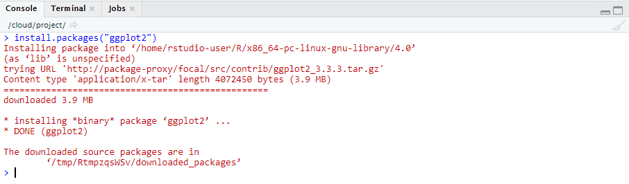

## Install packages melalui panel packages

Untuk cara yang kedua ini adalah menginstall packages melalui panel *packages*. Ada 2 tab pilihan yaitu *Install* dan *Update*. Tab *Install* digunakan untuk menginstall packages yang diinginkan, dengan cara memasukkan nama packages yang ingin diinstall kemudian mengklik tombol *Install*.

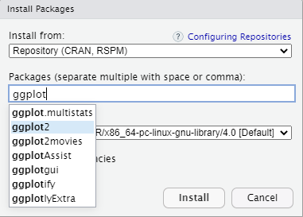

Tab *Update* digunakan untuk memperbaruhi versi dari packages, dengan cara memilih nama packages dan mengklik tombol *Install Update*

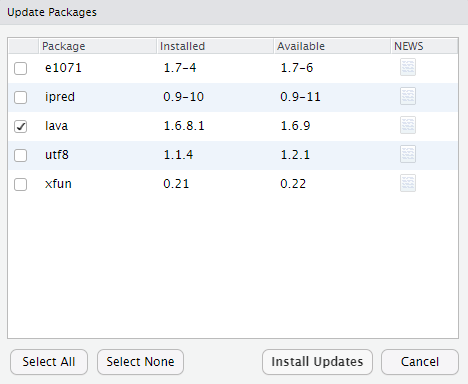

Cara memanggil library dalam R, dengan menggunkan fungsi `library()`

```r
# Load Packages/Library
# Packages untuk visualisasi
library(ggplot2)
# Packages untuk manipulasi data
library(dplyr)
head(retail)
```

|  | InvoiceNo | StockCode | Description | Quantity | InvoiceDate | UnitPrice | CustomerID | Country |
| --- | --- | --- | --- | --- | --- | --- | --- | --- |
| 1 | 536365 | 85123A | white hanging heart t-light holder | 6 | 12/1/2010 8:26 | 2.55 | 17850 | United Kingdom |
| 2 | 536365 | 71053 | white metal lantern | 6 | 12/1/2010 8:26 | 3.39 | 17850 | United Kingdom |
| 3 | 536365 | 84406B | cream cupid hearts coat hanger | 8 | 12/1/2010 8:26 | 2.75 | 17850 | United Kingdom |
| 4 | 536365 | 84029G | knitted union flag hot water bottle | 6 | 12/1/2010 8:26 | 3.39 | 17850 | United Kingdom |
| 5 | 536365 | 84029E | red woolly hottie white heart. | 6 | 12/1/2010 8:26 | 3.39 | 17850 | United Kingdom |
| 6 | 536365 | 22752 | set 7 babushka nesting boxes | 2 | 12/1/2010 8:26 | 7.65 | 17850 | United Kingdom |

Contoh penggunaan *library ggplot2*

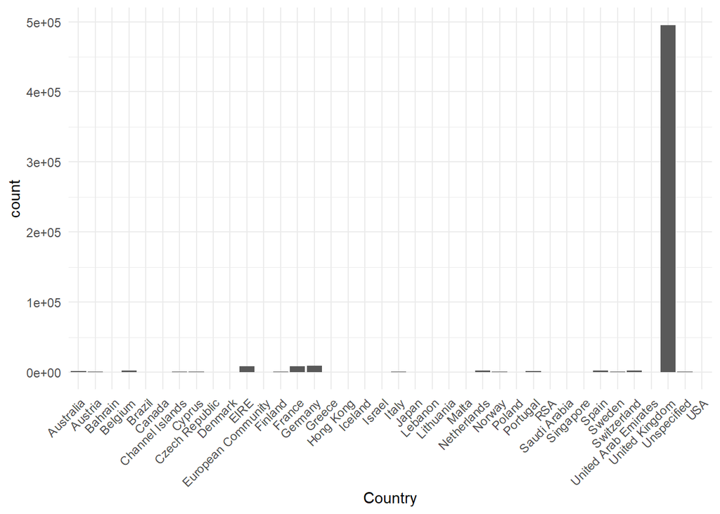

```r
ggplot(retail) +
  aes(x = Country) +
  geom_bar() + # grafik batang
  theme_minimal() +
  theme(axis.text.x = element_text(angle = 45, hjust = 1))
```

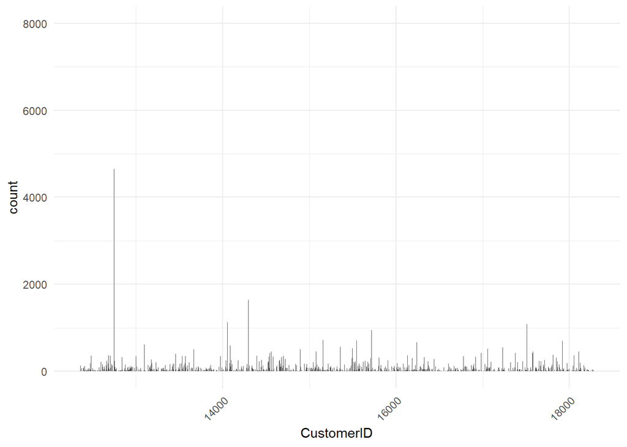

```r
ggplot(retail) +
  aes(x = CustomerID) +
  geom_bar() + # grafik batang
  theme_minimal() +
  theme(axis.text.x = element_text(angle = 45, hjust = 1))
```

```r
str(risk)
```

```
## tibble [425 × 12] (S3: tbl_df/tbl/data.frame)
##  $ LoanPurpose   : chr [1:425] "Small Appliance" "Furniture" "New Car" "Furniture" ...
##  $ Checking      : num [1:425] 0 0 0 638 963 ...
##  $ Savings       : num [1:425] 739 1230 389 347 4754 ...
##  $ MonthsCustomer: num [1:425] 13 25 19 13 40 11 13 14 37 25 ...
##  $ MonthsEmployed: num [1:425] 12 0 119 14 45 13 16 2 9 4 ...
##  $ Gender        : chr [1:425] "M" "M" "M" "M" ...
##  $ MaritalStatus : chr [1:425] "Single" "Divorced" "Single" "Single" ...
##  $ Age           : num [1:425] 23 32 38 36 31 25 26 27 25 43 ...
##  $ Housing       : chr [1:425] "Own" "Own" "Own" "Own" ...
##  $ Years         : num [1:425] 3 1 4 2 3 1 3 1 2 1 ...
##  $ Job           : chr [1:425] "Unskilled" "Skilled" "Management" "Unskilled" ...
##  $ CreditRisk    : chr [1:425] "Low" "High" "High" "High" ...
```

```r
head(risk)
```

| LoanPurpose | Checking | Savings | MonthsCustomer | MonthsEmployed | Gender | MaritalStatus | Age | Housing | Years | Job | CreditRisk |
| --- | --- | --- | --- | --- | --- | --- | --- | --- | --- | --- | --- |
| Small Appliance | 0 | 739 | 13 | 12 | M | Single | 23 | Own | 3 | Unskilled | Low |
| Furniture | 0 | 1230 | 25 | 0 | M | Divorced | 32 | Own | 1 | Skilled | High |
| New Car | 0 | 389 | 19 | 119 | M | Single | 38 | Own | 4 | Management | High |
| Furniture | 638 | 347 | 13 | 14 | M | Single | 36 | Own | 2 | Unskilled | High |
| Education | 963 | 4754 | 40 | 45 | M | Single | 31 | Rent | 3 | Skilled | Low |
| Furniture | 2827 | 0 | 11 | 13 | M | Married | 25 | Own | 1 | Skilled | Low |

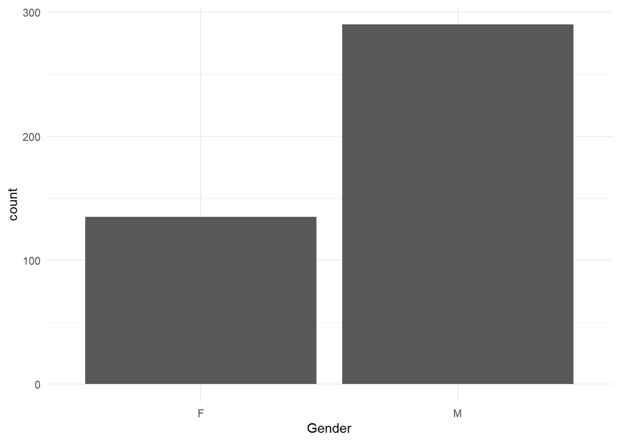

```r
ggplot(risk) +
  aes(x = Gender) +
  geom_bar() +
  theme_minimal()
```

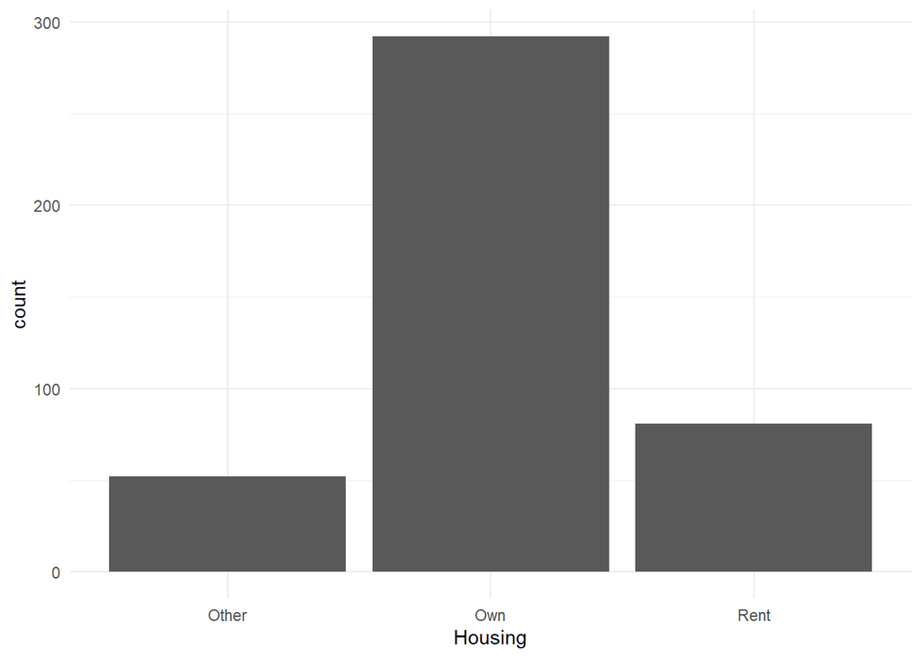

```r
ggplot(risk) +
  aes(x = Housing) +
  geom_bar() +
  theme_minimal()
```

*Latihan* 1. buatlah grafik dengan `geom_bar()` untuk menampilkan variabel `Job` dari objek `risk`

```r
# your code
```

2. buatlah grafik dengan `geom_bar()` untuk menampilkan varibel `MaritalStatus` dari objek `risk`

```r
# your code
```

library `dplyr` atau library untuk manipulasi data

fungsi str() untuk melihat struktur data. dengan dplyr untuk melihat struktur data kita menggunakan fungsi `glimpse()`

```r
glimpse(risk)
```

```
## Rows: 425
## Columns: 12
## $ LoanPurpose    <chr> "Small Appliance", "Furniture", "New Car", "Furniture",…
## $ Checking       <dbl> 0, 0, 0, 638, 963, 2827, 0, 0, 6509, 966, 0, 0, 322, 0,…
## $ Savings        <dbl> 739, 1230, 389, 347, 4754, 0, 229, 533, 493, 0, 989, 33…
## $ MonthsCustomer <dbl> 13, 25, 19, 13, 40, 11, 13, 14, 37, 25, 49, 11, 10, 25,…
## $ MonthsEmployed <dbl> 12, 0, 119, 14, 45, 13, 16, 2, 9, 4, 0, 15, 14, 63, 26,…
## $ Gender         <chr> "M", "M", "M", "M", "M", "M", "M", "M", "M", "F", "M", …
## $ MaritalStatus  <chr> "Single", "Divorced", "Single", "Single", "Single", "Ma…
## $ Age            <dbl> 23, 32, 38, 36, 31, 25, 26, 27, 25, 43, 32, 34, 26, 44,…
## $ Housing        <chr> "Own", "Own", "Own", "Own", "Rent", "Own", "Own", "Own"…
## $ Years          <dbl> 3, 1, 4, 2, 3, 1, 3, 1, 2, 1, 2, 2, 1, 1, 3, 4, 2, 2, 4…
## $ Job            <chr> "Unskilled", "Skilled", "Management", "Unskilled", "Ski…
## $ CreditRisk     <chr> "Low", "High", "High", "High", "Low", "Low", "Low", "Lo…
```

```r
head(risk)
```

| LoanPurpose | Checking | Savings | MonthsCustomer | MonthsEmployed | Gender | MaritalStatus | Age | Housing | Years | Job | CreditRisk |
| --- | --- | --- | --- | --- | --- | --- | --- | --- | --- | --- | --- |
| Small Appliance | 0 | 739 | 13 | 12 | M | Single | 23 | Own | 3 | Unskilled | Low |
| Furniture | 0 | 1230 | 25 | 0 | M | Divorced | 32 | Own | 1 | Skilled | High |
| New Car | 0 | 389 | 19 | 119 | M | Single | 38 | Own | 4 | Management | High |
| Furniture | 638 | 347 | 13 | 14 | M | Single | 36 | Own | 2 | Unskilled | High |
| Education | 963 | 4754 | 40 | 45 | M | Single | 31 | Rent | 3 | Skilled | Low |
| Furniture | 2827 | 0 | 11 | 13 | M | Married | 25 | Own | 1 | Skilled | Low |

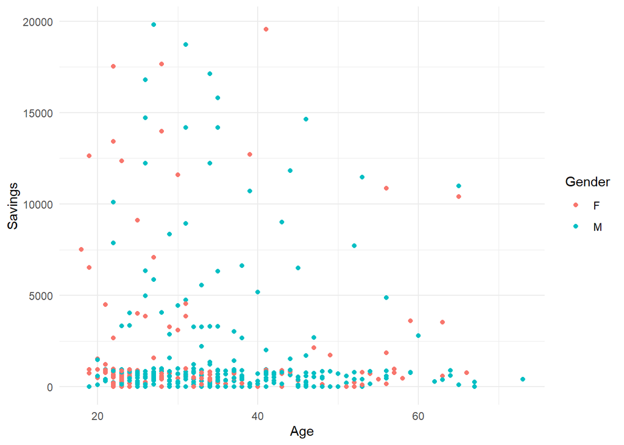

```r
ggplot(risk)+
  aes(x = Age, y = Savings, colour = Gender) +
  geom_point() + #grafik titik
  theme_minimal() +
  scale_color_hue()
```

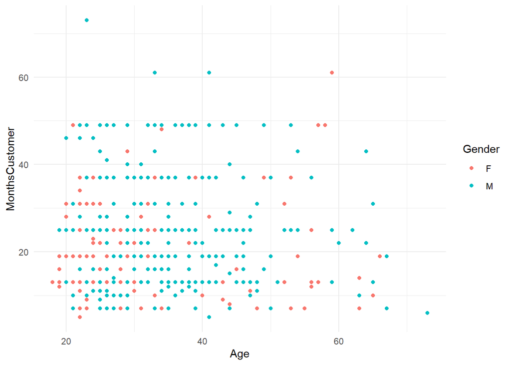

```r
ggplot(risk)+
  aes(x = Age, y = MonthsCustomer, colour = Gender) +
  geom_point() + #grafik titik
  theme_minimal() +
  scale_color_hue()
```

```r
head(sales)
```

| Date | Day | Time | Region | Card Type | Gender | Buy Category | Items Ordered | Total Cost | High Item |
| --- | --- | --- | --- | --- | --- | --- | --- | --- | --- |
| 2016-03-06 | Sun | Morning | West | ElecMart | Female | High | 4 | 136.97 | 79.97 |
| 2016-03-06 | Sun | Morning | West | Other | Female | Medium | 1 | 25.55 | 25.55 |
| 2016-03-06 | Sun | Afternoon | West | ElecMart | Female | Medium | 5 | 113.95 | 90.47 |
| 2016-03-06 | Sun | Afternoon | NorthEast | Other | Female | Low | 1 | 6.82 | 6.82 |
| 2016-03-06 | Sun | Afternoon | West | ElecMart | Male | Medium | 4 | 147.32 | 83.21 |
| 2016-03-06 | Sun | Afternoon | NorthEast | Other | Female | Medium | 5 | 142.15 | 50.90 |

```r
head(risk)
```

| LoanPurpose | Checking | Savings | MonthsCustomer | MonthsEmployed | Gender | MaritalStatus | Age | Housing | Years | Job | CreditRisk |
| --- | --- | --- | --- | --- | --- | --- | --- | --- | --- | --- | --- |
| Small Appliance | 0 | 739 | 13 | 12 | M | Single | 23 | Own | 3 | Unskilled | Low |
| Furniture | 0 | 1230 | 25 | 0 | M | Divorced | 32 | Own | 1 | Skilled | High |
| New Car | 0 | 389 | 19 | 119 | M | Single | 38 | Own | 4 | Management | High |
| Furniture | 638 | 347 | 13 | 14 | M | Single | 36 | Own | 2 | Unskilled | High |
| Education | 963 | 4754 | 40 | 45 | M | Single | 31 | Rent | 3 | Skilled | Low |
| Furniture | 2827 | 0 | 11 | 13 | M | Married | 25 | Own | 1 | Skilled | Low |

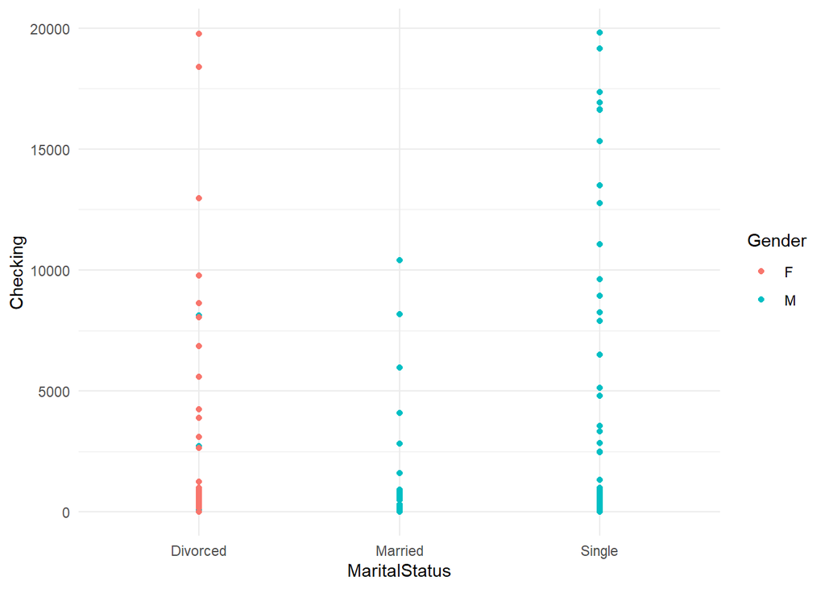

```r
ggplot(risk)+
  aes(x = MaritalStatus, y = Checking, colour = Gender) +
  geom_point() +
  theme_minimal() +
  scale_color_hue()
```

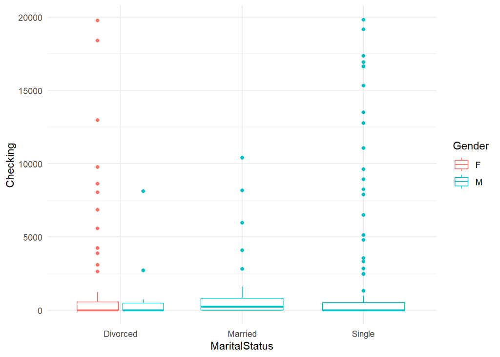

```r
ggplot(risk)+
  aes(x = MaritalStatus, y = Checking, colour = Gender) +
  geom_boxplot() +
  theme_minimal() +
  scale_color_hue()
```

```r
head(sales)
```

| Date | Day | Time | Region | Card Type | Gender | Buy Category | Items Ordered | Total Cost | High Item |
| --- | --- | --- | --- | --- | --- | --- | --- | --- | --- |
| 2016-03-06 | Sun | Morning | West | ElecMart | Female | High | 4 | 136.97 | 79.97 |
| 2016-03-06 | Sun | Morning | West | Other | Female | Medium | 1 | 25.55 | 25.55 |
| 2016-03-06 | Sun | Afternoon | West | ElecMart | Female | Medium | 5 | 113.95 | 90.47 |
| 2016-03-06 | Sun | Afternoon | NorthEast | Other | Female | Low | 1 | 6.82 | 6.82 |
| 2016-03-06 | Sun | Afternoon | West | ElecMart | Male | Medium | 4 | 147.32 | 83.21 |
| 2016-03-06 | Sun | Afternoon | NorthEast | Other | Female | Medium | 5 | 142.15 | 50.90 |

```r
glimpse(sales)
```

```
## Rows: 400
## Columns: 10
## $ Date            <dttm> 2016-03-06, 2016-03-06, 2016-03-06, 2016-03-06, 2016-…
## $ Day             <chr> "Sun", "Sun", "Sun", "Sun", "Sun", "Sun", "Mon", "Mon"…
## $ Time            <chr> "Morning", "Morning", "Afternoon", "Afternoon", "After…
## $ Region          <chr> "West", "West", "West", "NorthEast", "West", "NorthEas…
## $ `Card Type`     <chr> "ElecMart", "Other", "ElecMart", "Other", "ElecMart", …
## $ Gender          <chr> "Female", "Female", "Female", "Female", "Male", "Femal…
## $ `Buy Category`  <chr> "High", "Medium", "Medium", "Low", "Medium", "Medium",…
## $ `Items Ordered` <dbl> 4, 1, 5, 1, 4, 5, 1, 4, 2, 1, 2, 2, 3, 1, 3, 5, 6, 4, …
## $ `Total Cost`    <dbl> 136.97, 25.55, 113.95, 6.82, 147.32, 142.15, 18.65, 17…
## $ `High Item`     <dbl> 79.97, 25.55, 90.47, 6.82, 83.21, 50.90, 18.65, 161.93…
```

```r
# Merubah nama kolom dari variabel menjadi satu kata agar mudah digunakan dalam fungsi ggplot2
colnames(sales)[colnames(sales) == "Items Ordered"] <- "ItemsOrdered"
colnames(sales)[colnames(sales) == "Card Type"] <- "CardType"
colnames(sales)[colnames(sales) == "Buy Category"] <- "BuyCategory"
colnames(sales)[colnames(sales) == "Total Cost"] <- "TotalCost"
colnames(sales)[colnames(sales) == "High Item"] <- "HighItem"
glimpse(sales)
```

```
## Rows: 400
## Columns: 10
## $ Date         <dttm> 2016-03-06, 2016-03-06, 2016-03-06, 2016-03-06, 2016-03-…
## $ Day          <chr> "Sun", "Sun", "Sun", "Sun", "Sun", "Sun", "Mon", "Mon", "…
## $ Time         <chr> "Morning", "Morning", "Afternoon", "Afternoon", "Afternoo…
## $ Region       <chr> "West", "West", "West", "NorthEast", "West", "NorthEast",…
## $ CardType     <chr> "ElecMart", "Other", "ElecMart", "Other", "ElecMart", "Ot…
## $ Gender       <chr> "Female", "Female", "Female", "Female", "Male", "Female",…
## $ BuyCategory  <chr> "High", "Medium", "Medium", "Low", "Medium", "Medium", "L…
## $ ItemsOrdered <dbl> 4, 1, 5, 1, 4, 5, 1, 4, 2, 1, 2, 2, 3, 1, 3, 5, 6, 4, 1, …
## $ TotalCost    <dbl> 136.97, 25.55, 113.95, 6.82, 147.32, 142.15, 18.65, 178.3…
## $ HighItem     <dbl> 79.97, 25.55, 90.47, 6.82, 83.21, 50.90, 18.65, 161.93, 1…
```

```r
head(sales)
```

| Date | Day | Time | Region | CardType | Gender | BuyCategory | ItemsOrdered | TotalCost | HighItem |
| --- | --- | --- | --- | --- | --- | --- | --- | --- | --- |
| 2016-03-06 | Sun | Morning | West | ElecMart | Female | High | 4 | 136.97 | 79.97 |
| 2016-03-06 | Sun | Morning | West | Other | Female | Medium | 1 | 25.55 | 25.55 |
| 2016-03-06 | Sun | Afternoon | West | ElecMart | Female | Medium | 5 | 113.95 | 90.47 |
| 2016-03-06 | Sun | Afternoon | NorthEast | Other | Female | Low | 1 | 6.82 | 6.82 |
| 2016-03-06 | Sun | Afternoon | West | ElecMart | Male | Medium | 4 | 147.32 | 83.21 |
| 2016-03-06 | Sun | Afternoon | NorthEast | Other | Female | Medium | 5 | 142.15 | 50.90 |

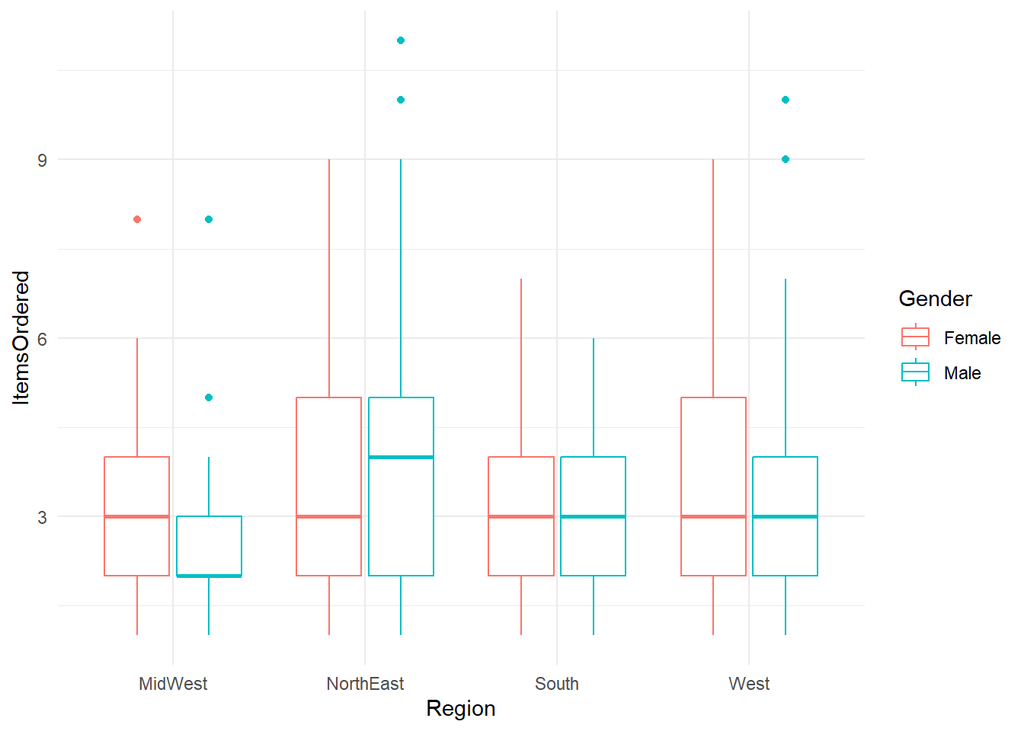

```r
ggplot(sales)+
  aes(x = Region, y = ItemsOrdered, colour = Gender) +
  geom_boxplot() +
  theme_minimal() +
  scale_color_hue()
```

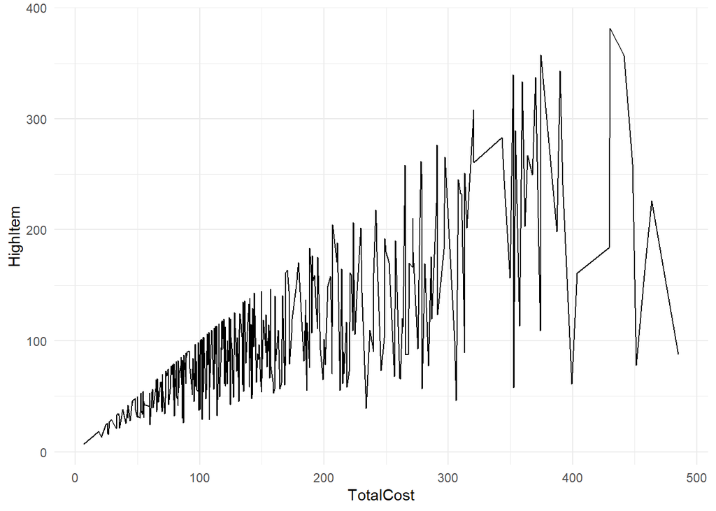

```r
ggplot(sales)+
  aes(x = TotalCost, y = HighItem) +
  geom_line() +
  theme_minimal() +
  scale_color_hue()
```

Berikut ini, grafik defult yang ada dalam R

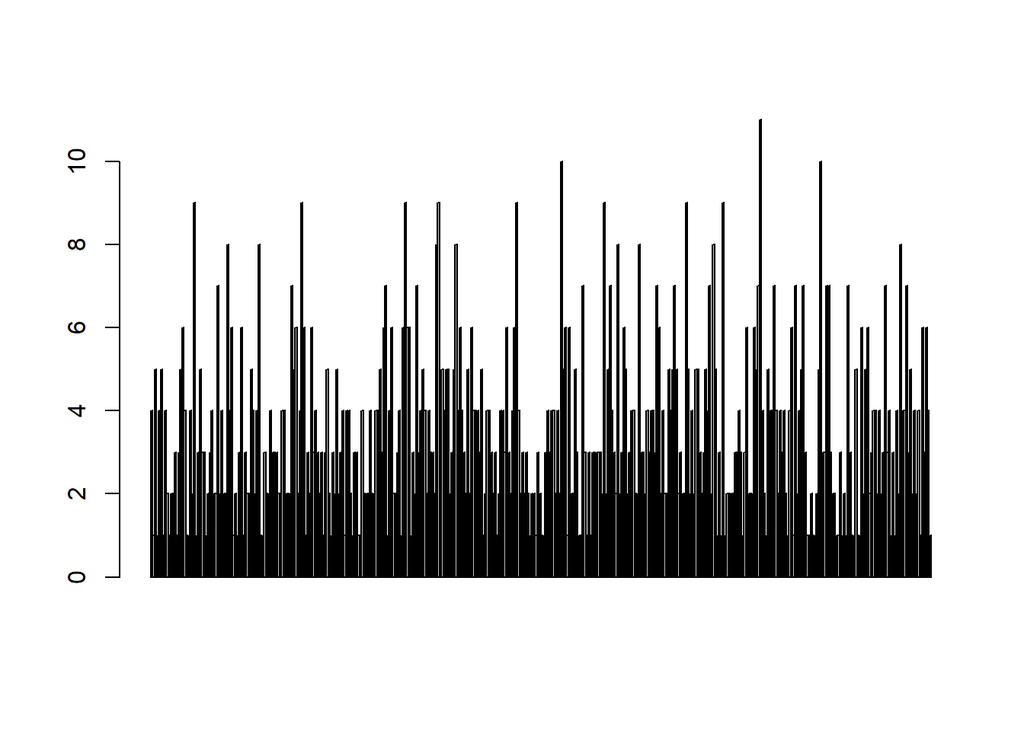

```r
barplot(sales$ItemsOrdered)
```

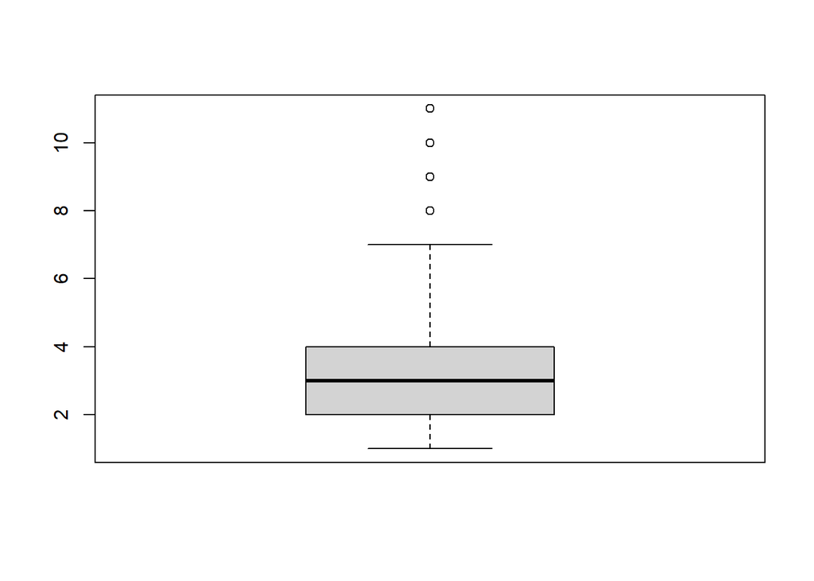

```r
boxplot(sales$ItemsOrdered)
```

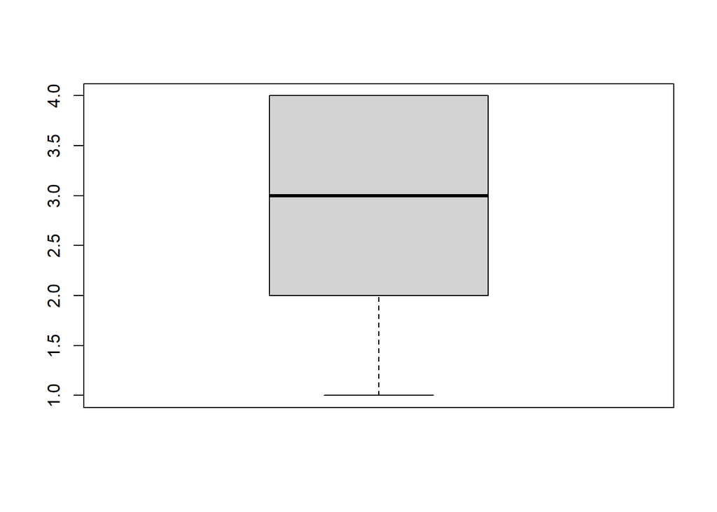

```r
boxplot(risk$Years)
```

# Penutup

Demikian pembahasan kita tentang R untuk Analisis Data, semoga materi ini bisa Anda jadikan sebagai dasar untuk mengikuti materi-materi selanjutnya. *Selamat belajar dan salam sehat selalu*